# Determining Heavy Traffic Indicators

### 1. Introduction

Heavy traffic is a growing problem in several countries around the world. It is problematic for different reasons. Heavy traffic has a negative impact on the environment as well as life quality for those who have to spend hours to commute between their homes and workplaces. Also, the economic costs of heavy traffic can be enormous, with several countries losing billions of dollars every year as a result. This research project aims to determine a few indicators of heavy traffic, and uses a dataset about westbound traffic on the I-94 Interstate highway connecting several regions in the northern parts of the United States.

### 2. Importing and Exploring the Dataset

```python
import pandas as pd
import numpy as np
```

```python
traffic = pd.read_csv('Metro_Interstate_Traffic_Volume.csv')
print(traffic.head())
```

```
  holiday    temp  rain_1h  snow_1h  clouds_all weather_main  \
0    None  288.28      0.0      0.0          40       Clouds
1    None  289.36      0.0      0.0          75       Clouds
2    None  289.58      0.0      0.0          90       Clouds
3    None  290.13      0.0      0.0          90       Clouds
4    None  291.14      0.0      0.0          75       Clouds

  weather_description            date_time  traffic_volume
0    scattered clouds  2012-10-02 09:00:00            5545
1       broken clouds  2012-10-02 10:00:00            4516
2     overcast clouds  2012-10-02 11:00:00            4767
3     overcast clouds  2012-10-02 12:00:00            5026
4       broken clouds  2012-10-02 13:00:00            4918
```

```python
print(traffic.tail())
```

```
      holiday    temp  rain_1h  snow_1h  clouds_all  weather_main  \
48199    None  283.45      0.0      0.0          75        Clouds
48200    None  282.76      0.0      0.0          90        Clouds
48201    None  282.73      0.0      0.0          90  Thunderstorm
48202    None  282.09      0.0      0.0          90        Clouds
48203    None  282.12      0.0      0.0          90        Clouds

          weather_description            date_time  traffic_volume
48199           broken clouds  2018-09-30 19:00:00            3543
48200         overcast clouds  2018-09-30 20:00:00            2781
48201  proximity thunderstorm  2018-09-30 21:00:00            2159
48202         overcast clouds  2018-09-30 22:00:00            1450
48203         overcast clouds  2018-09-30 23:00:00             954
```

```python
print(traffic.info())
```

```
<class 'pandas.core.frame.DataFrame'>
RangeIndex: 48204 entries, 0 to 48203
Data columns (total 9 columns):
 #   Column               Non-Null Count  Dtype
---  ------               --------------  -----
 0   holiday              48204 non-null  object
 1   temp                 48204 non-null  float64
 2   rain_1h              48204 non-null  float64
 3   snow_1h              48204 non-null  float64
 4   clouds_all           48204 non-null  int64
 5   weather_main         48204 non-null  object
 6   weather_description  48204 non-null  object
 7   date_time            48204 non-null  object
 8   traffic_volume       48204 non-null  int64
dtypes: float64(3), int64(2), object(4)
memory usage: 3.3+ MB
None
```

Looking at the dataset, we observe that all columns contain 48,204 rows. Conveniently, this means that the dataset appears to be complete. It consists of nine columns, six of which contain information about the weather. The other three columns store information about whether a particular day was a holiday, the date and time (combined into one column) and, importantly, the traffic volume. Analyzing and visualizing the relationships between traffic volume and the other variables may help us develop an understanding of the determinants of heavy traffic. We will start with an analysis of the traffic volume itself.

### 3. Analyzing Traffic Volume

```python
import matplotlib.pyplot as plt
%matplotlib inline
```

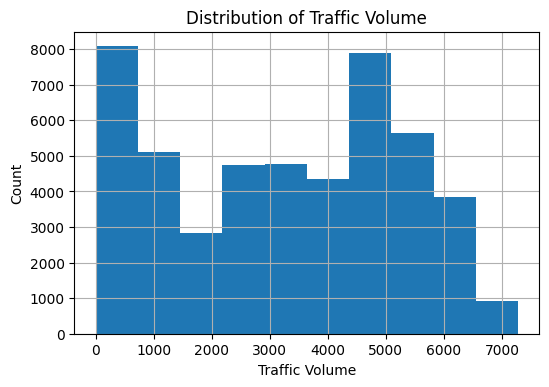

```python
traffic['traffic_volume'].hist()
plt.xlabel('Traffic Volume')
plt.ylabel('Count')
plt.title('Distribution of Traffic Volume')
plt.show()
```

The histogram above displays the distribution of traffic volume on the I-94 Interstate highway. What it exactly shows is the number of vehicles that pass the test station per hour. Note that one row in the dataset represents the different variables for one hour. The horizontal axis displays ten binned clusters of traffic volume, each bar representing an incremental increase of roughly 700. The vertical axis shows the frequency of the observed traffic volume.

We observe a skewed bimodal distribution of traffic volume. While the mean value of the `traffic_volume` column is 3,259.82 - see the descriptive statistics table below - the actual frequency of such traffic volumes is rather low. Especially the first and seventh bars in the histogram however, are remarkably higher. This implies that there have been many observations of traffic volumes that are either substantially lower or higher than the average traffic volume. In other words, the I-94 highway is regularly either (close to) empty, or quite busy. This observation is further supported by the descriptive statistics table below, which indicates that about 25 per cent of the time, there are **1,193 or less** vehicles on the road. Also, about 25 per cent of the time, there are **4,933 or more*** vehicles on the road, which is more than four times as much as in the lowest quartile.

An obvious first guess would be that this bimodal distribution signifies the difference between daytime and nighttime. This will be the next point of focus.

```python
print('Traffic Volume: Descriptive Statistics')
print()
print(traffic['traffic_volume'].describe())
```

```
Traffic Volume: Descriptive Statistics

count    48204.000000
mean      3259.818355
std       1986.860670
min          0.000000
25%       1193.000000
50%       3380.000000
75%       4933.000000
max       7280.000000
Name: traffic_volume, dtype: float64
```

### 4. Traffic Volume: Day and Night

```python
# converting the 'date_time' column from string format to a datetime object
traffic['date_time'] = pd.to_datetime(traffic['date_time'])
```

```python
# adding an 'hour' column to get the hour of every instance
traffic['hour'] = traffic['date_time'].dt.hour
```

```python
# isolating daytime and nighttime data into two dataframes
dt_traffic = traffic[(traffic['hour'] >= 7) & (traffic['hour'] <= 19)].copy()
nt_traffic = traffic[(traffic['hour'] < 7) | (traffic['hour'] > 19)]
```

```python
print('Daytime traffic: number of rows and columns')
print(dt_traffic.shape)
print()
print('Nighttime traffic: number of rows and columns')
print(nt_traffic.shape)
```

```
Daytime traffic: number of rows and columns
(25838, 10)

Nighttime traffic: number of rows and columns
(22366, 10)
```

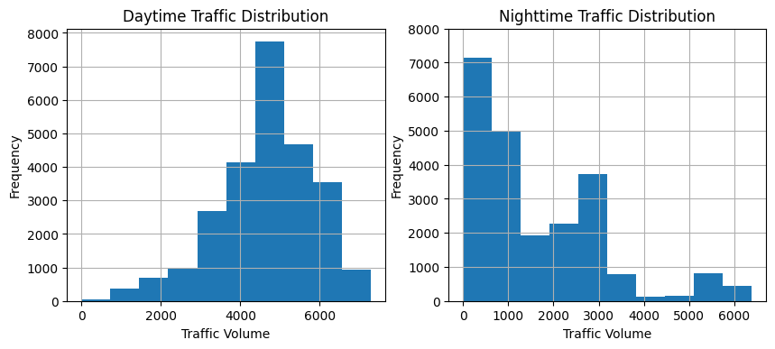

```python
plt.figure(figsize=(10,4))

plt.subplot(1,2,1)
dt_traffic['traffic_volume'].hist()
plt.title('Daytime Traffic Distribution')
plt.xlabel('Traffic Volume')
plt.ylabel('Frequency')

plt.subplot(1,2,2)
nt_traffic['traffic_volume'].hist()
plt.title('Nighttime Traffic Distribution')
plt.xlabel('Traffic Volume')
plt.ylabel('Frequency')

plt.ylim([0,8000])
plt.show()
```

In the code above, we have split the data into a daytime dataset and a nighttime dataset. By doing so, we can analyze the daytime and nighttime traffic distributions separately. The daytime dataset contains all instances between 07:00 a.m. and 07:00 p.m. (or 19:00), and the nighttime dataset contains the instances between 07:00 p.m. (or 19:00) and 07:00 a.m.

```python
print('Daytime Traffic: Descriptive Statistics')
print(dt_traffic['traffic_volume'].describe())
print()
print('Nighttime Traffic: Descriptive Statistics')
print(nt_traffic['traffic_volume'].describe())
```

```
Daytime Traffic: Descriptive Statistics
count    25838.000000
mean      4649.292360
std       1202.321987
min          0.000000
25%       4021.000000
50%       4736.000000
75%       5458.000000
max       7280.000000
Name: traffic_volume, dtype: float64

Nighttime Traffic: Descriptive Statistics
count    22366.000000
mean      1654.648484
std       1425.175292
min          0.000000
25%        486.000000
50%       1056.500000
75%       2630.750000
max       6386.000000
Name: traffic_volume, dtype: float64
```

### 5. Time Indicators: Months

```python
# creating a month column
dt_traffic['month'] = dt_traffic['date_time'].dt.month

# grouping the data by month and calculate the mean traffic volume for each
traffic_month = dt_traffic.groupby('month').mean()

traffic_month['traffic_volume']
```

```
month
1     4385.217310
2     4593.187798
3     4761.529676
4     4771.232816
5     4788.966639
6     4791.087488
7     4502.628360
8     4818.434690
9     4755.709916
10    4809.481678
11    4588.910486
12    4276.567081
Name: traffic_volume, dtype: float64
```

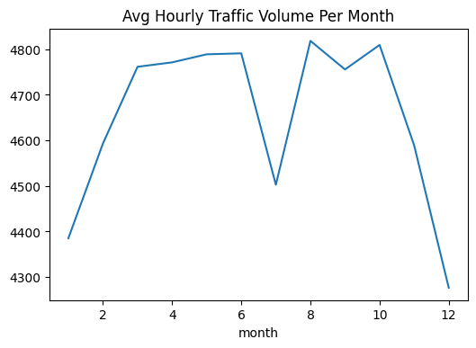

```python
traffic_month['traffic_volume'].plot()
plt.title('Avg Hourly Traffic Volume Per Month')
plt.show()
```

In the code above, we've created a new column, `month`, which helps us calculate the mean value for each month's traffic volume. We have then plotted this information into a line chart, so that we can intuitively make observations about the monthly distribution of traffic volume. The line chart shows a quite constant value between roughly 4,700 and 4,800 vehicles per hour for most of the months. However, we observe sharp declines in the month of July and the period of December to February. This might hint towards seasonal factors, such as temperatures and holidays.

### 6. Time Indicators: Days of the Week

```python
# creating a day of the week column
dt_traffic['dayofweek'] = dt_traffic['date_time'].dt.dayofweek

# grouping the data by day of the week and calculate the mean traffic volume for each
traffic_dow = dt_traffic.groupby('dayofweek').mean()

traffic_dow['traffic_volume']
```

```
dayofweek
0    4746.208029
1    5036.062431
2    5141.231163
3    5163.688063
4    5161.533588
5    3884.065668
6    3410.368091
Name: traffic_volume, dtype: float64
```

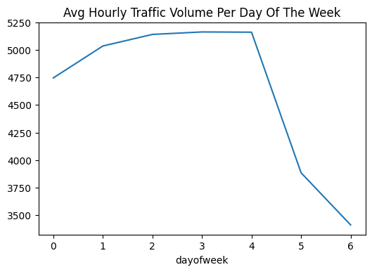

```python
traffic_dow['traffic_volume'].plot()
plt.title('Avg Hourly Traffic Volume Per Day Of The Week')
plt.show()
```

Similar to the previous step, we've calculated and extracted the day of the week from the `date_time` column and stored it in a new column, `dayofweek`. We have then plotted the new data into a line chart. A clear pattern is visible: during the first five days of the week, the average number of vehicles per hour lies constantly between roughly 4,750 and 5,200, and then falls below 4,000 on the sixth day and even below 3,500 on the seventh day. Just like seasonal effects and holidays can be thought of as indicators of lower traffic volume, the weekend also shows much lower traffic volumes than working days. One may assume that commuting between work and home constitutes a significant part of the traffic volume during working days.

### 7. Time Indicators: Time of the Day

```python
# splitting the dataset into working days and weekend days
working_days = dt_traffic.copy()[dt_traffic['dayofweek'] <= 4]
weekend = dt_traffic.copy()[dt_traffic['dayofweek'] >= 5]

wd_hour = working_days.groupby('hour').mean()
we_hour = weekend.groupby('hour').mean()

print(wd_hour['traffic_volume'])
print()
print(we_hour['traffic_volume'])
```

```
hour
7     6030.413559
8     5503.497970
9     4895.269257
10    4378.419118
11    4633.419470
12    4855.382143
13    4859.180473
14    5152.995778
15    5592.897768
16    6189.473647
17    5784.827133
18    4434.209431
19    3298.340426
Name: traffic_volume, dtype: float64
```

[output cut: 16 more lines]

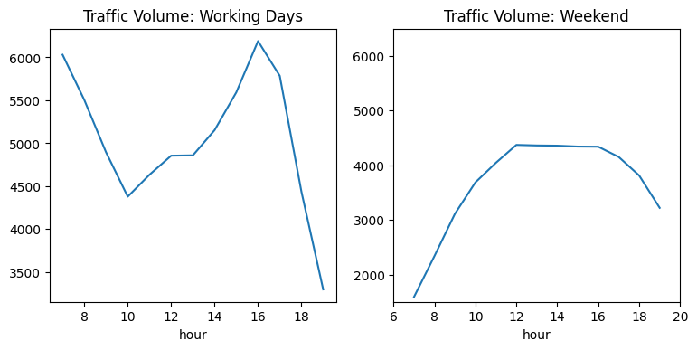

```python
plt.figure(figsize=(9,4))
plt.subplot(1,2,1)
wd_hour['traffic_volume'].plot()
plt.title('Traffic Volume: Working Days')

plt.subplot(1,2,2)
we_hour['traffic_volume'].plot()
plt.title('Traffic Volume: Weekend')

plt.xlim([6,20])
plt.ylim([1500,6500])

plt.show()
```

Comparing the hourly traffic volume during working days and weekend days, we observe a striking difference. On working days, the morning and late afternoon rush hours see large spikes in traffic volume. After 6:00 p.m. (or 18:00), the traffic volume decreases sharply. Here too, commuting may account for a significant part of heavy traffic. The weekend chart shows a different pattern, with lighter traffic in the early morning and early evening, and higher traffic volumes during the day. One explanation could be that less people are working during the weekend. And those who are free may spend their time shopping, leisure, visiting friends and relatives, and other activities that often take place at daytime.

### 8. Weather Indicators

So far, our focus of this project has been on time indicators. We have analyzed the differences in traffic volume between daytime and nighttime, months, days of the week, and hours during working days and weekend days. The monthly chart showed a pattern of heavier traffic during warm months and lighter traffic during cold months, with July being the exception. Another possible indicator of heavy traffic is weather. The I-94 Interstate highway dataset provides us with a few useful variables about the weather. These are:

- `temp` - the average hourly temperature in kelvin
- `rain_1h` - the amount of rain that occurred in the hour, in millimetres
- `snow_1h` - the amount of snow that occurred in the hour, in millimetres
- `clouds_all` - the percentage of cloud cover
- `weather_main` - short textual description of the current weather
- `weather_discription` - a categorical, longer textual description of the current weather

The first four columns are all numeric columns. This enables us to examine their correlation values with `traffic_volume`. The output will be evaluated below.

```python
print(dt_traffic.info())
```

```
<class 'pandas.core.frame.DataFrame'>
Int64Index: 25838 entries, 0 to 48199
Data columns (total 12 columns):
 #   Column               Non-Null Count  Dtype
---  ------               --------------  -----
 0   holiday              25838 non-null  object
 1   temp                 25838 non-null  float64
 2   rain_1h              25838 non-null  float64
 3   snow_1h              25838 non-null  float64
 4   clouds_all           25838 non-null  int64
 5   weather_main         25838 non-null  object
 6   weather_description  25838 non-null  object
 7   date_time            25838 non-null  datetime64[ns]
 8   traffic_volume       25838 non-null  int64
 9   hour                 25838 non-null  int64
 10  month                25838 non-null  int64
 11  dayofweek            25838 non-null  int64
dtypes: datetime64[ns](1), float64(3), int64(5), object(3)
memory usage: 2.6+ MB
None
```

```python
dtf = dt_traffic.copy()[['temp', 'rain_1h', 'snow_1h', 'clouds_all', 'traffic_volume']]
dtf.corr()['traffic_volume']
```

```
temp              0.118084
rain_1h           0.004020
snow_1h           0.003768
clouds_all       -0.033410
traffic_volume    1.000000
Name: traffic_volume, dtype: float64
```

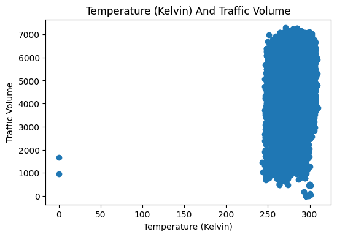

```python
plt.scatter(dt_traffic['temp'], dt_traffic['traffic_volume'])
plt.title('Temperature (Kelvin) And Traffic Volume')
plt.xlabel('Temperature (Kelvin)')
plt.ylabel('Traffic Volume')
plt.show()
```

Looking at the correlation values, we observe low correlation values for all four weather indicators. The scatter plot of temperatures and traffic volumes exemplifies this. The temperatures constantly lie between roughly 250 and 300 degrees kelvin, and does not seem to affect traffic volumes in any significant way. Typical null correlations, these numeric weather indicators do not show a strongly positive or negative relationship between the weather and traffic volume. This is not very surprising, given our previous findings that commuting between home and work is most likely a major cause of heavy traffic, and may not be affected by temperatures, cloud and rain. However, we do have two other columns related to the weather, which will be investigated below.

### 9. Weather Types

While the four numeric weather columns contain valuable information, their practical use is limited for our research project. There are several weather related variables that are not captured by these four columns. For instance, the `rain_1h` and `snow_1h` columns do not tell us anything about how much rain or snow there has already been in the previous hours or days, nor do the four columns contain information about factors such as thunderstorms. Such factors may contribute to traffic congestion, so it is well worth investigating their impact on the traffic volume. We'll start by looking at the `weather_main` column, which gives a simple discription of the weather that occurred in each hour.

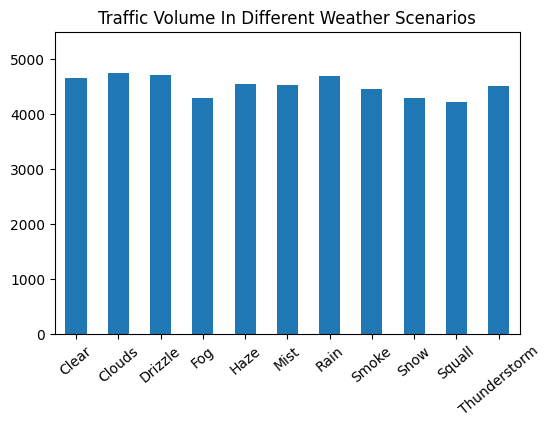

```python
# grouping the dataset by the two weather type columns
w_main = dt_traffic.groupby('weather_main').mean()
w_descr = dt_traffic.groupby('weather_description').mean()

plt.figure()
w_main['traffic_volume'].plot.bar()
plt.title('Traffic Volume In Different Weather Scenarios')
plt.xlabel('')
plt.ylim([0,5500])
plt.xticks(rotation=40)
plt.show()
```

Analyzing the main column does not result in important new findings. Rather, traffic volume is more or less equal for all weather scenarios, with traffic volume ranging between 4,000 and 5,000 on average for each weather scenario. Fortunately, we also have a column with more detailed descriptions of the weather. This one will be investigated below.

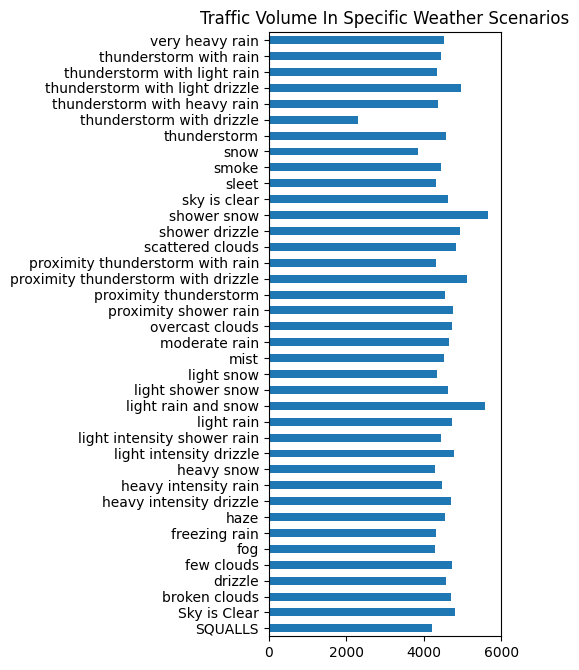

```python
plt.figure(figsize=(3,8))
w_descr['traffic_volume'].plot.barh()
plt.title('Traffic Volume In Specific Weather Scenarios')
plt.ylabel('')
plt.xlim([0,6000])
plt.show()
```

The `weather_description` column gives us more useful information. Two weather types stand out, which are 'shower snow' and 'light rain and snow'. This tells us that under specific conditions, snow may contribute to higher traffic volumes.

### 10. Conclusion

In this project we have aimed to identify indicators of heavy traffic. We've used a dataset compromised of westbound traffic data from the I-94 Interstate highway in the northern parts of the United States. We've found a binomal distribution of traffic volume, possibly caused by the very low traffic volume at nighttime. Daytime traffic volume showed a normal distribution, with peaks on working days around 07:00 and 16:00 and a more equal distribution of traffic volume on weekend days. Crucially, the data shows that overall traffic volume is much higher on working days than on weekend days, suggesting that commuting is a major cause of heavy traffic. We've also found that, except for July, a general pattern of higher traffic volumes in the warmer months (March-October) and lower traffic volumes in the colder months (November-February). However, weather indicators and weather types only show very low correlation to traffic volumes, with only shower snow and the combination of light rain and snow showing higher traffic volume. That being said, this project concludes with the finding that working days, rush hours and non-holiday months are probably the strongest indicators of heavy traffic.